# Tree-Based Sales Prediction using R

Sudheesh Sreenilayam

2025-05-12

# 1 📌 Introduction

This project explores tree-based regression models to predict product sales using the `Carseats` dataset from the **ISLR** package. Techniques covered include: - Regression Trees - Cross-validation and pruning - Bagging - Random Forests with tuned parameters - Variable importance interpretation

# 2 📦 Load Packages and Data

```r
if (!require("ISLR")) install.packages("ISLR", repos = "https://cloud.r-project.org")
if (!require("tree")) install.packages("tree", repos = "https://cloud.r-project.org")
if (!require("randomForest")) install.packages("randomForest", repos = "https://cloud.r-project.org")
if (!require("caTools")) install.packages("caTools", repos = "https://cloud.r-project.org")

library(ISLR)
library(tree)
library(randomForest)
library(caTools)
```

# 3 📊 Load and Split the Data

```r
set.seed(2)
data <- Carseats
split <- sample.split(data$Sales, SplitRatio = 0.7)
train <- subset(data, split == TRUE)
test <- subset(data, split == FALSE)
```

# 4 🌲 Regression Tree

```r
tree_model <- tree(Sales ~ ., data = train)
summary(tree_model)
```

```
##
## Regression tree:
## tree(formula = Sales ~ ., data = train)
## Variables actually used in tree construction:
## [1] "ShelveLoc"   "Price"       "Age"         "CompPrice"   "Education"
## [6] "Advertising"
## Number of terminal nodes:  18
## Residual mean deviance:  2.378 = 623 / 262
## Distribution of residuals:
##     Min.  1st Qu.   Median     Mean  3rd Qu.     Max.
## -4.07500 -1.03400  0.03614  0.00000  0.97940  3.89800
```

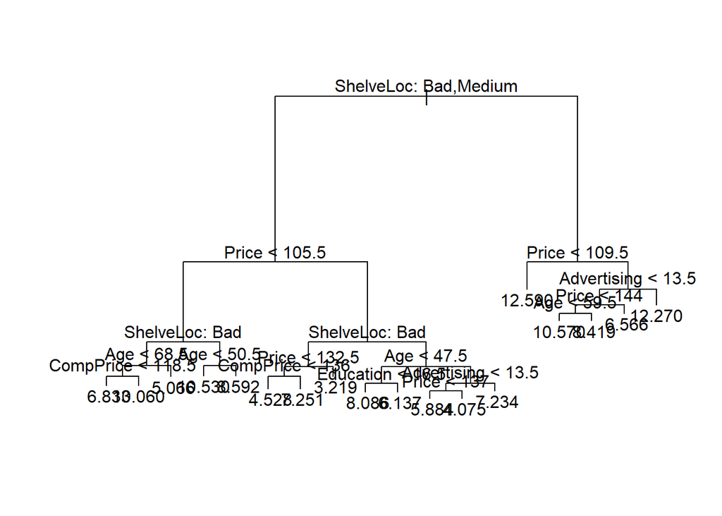

```r
plot(tree_model)
text(tree_model, pretty = 0)
```

```r
pred_tree <- predict(tree_model, newdata = test)
mse_tree <- mean((pred_tree - test$Sales)^2)
mse_tree
```

```
## [1] 4.974844
```

**Interpretation:** The regression tree was built using all predictors. The test set MSE provides a baseline for comparison with pruned and ensemble models.

# 5 ✂️ Tree Pruning via Cross-Validation

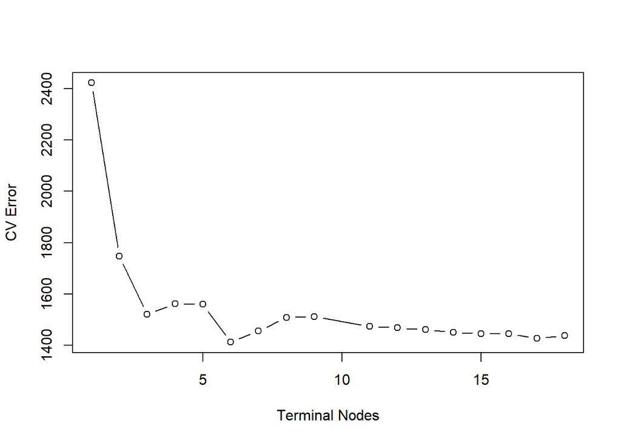

```r
set.seed(2)
cv <- cv.tree(tree_model)
plot(cv$size, cv$dev, type = "b", xlab = "Terminal Nodes", ylab = "CV Error")
```

```r
pruned_tree <- prune.tree(tree_model, best = 6)
pred_pruned <- predict(pruned_tree, newdata = test)
mse_pruned <- mean((pred_pruned - test$Sales)^2)
mse_pruned
```

```
## [1] 4.736453
```

**Interpretation:** Pruning reduced the size of the tree, leading to a slightly improved test MSE, indicating reduced overfitting.

# 6 👜 Bagging Model (Random Forest with all predictors)

```r
set.seed(2)
bag_model <- randomForest(Sales ~ ., data = train, mtry = 10, importance = TRUE)
bag_pred <- predict(bag_model, newdata = test)
mse_bagging <- mean((bag_pred - test$Sales)^2)
mse_bagging
```

```
## [1] 2.333523
```

```r
importance(bag_model)
```

```
##               %IncMSE IncNodePurity
## CompPrice   27.289181    198.955847
## Income      11.251338    117.530057
## Advertising 20.386728    139.299487
## Population  -1.039557     61.098096
## Price       72.603845    681.887184
## ShelveLoc   78.255525    797.073047
## Age         23.594252    249.958626
## Education    2.875787     60.119890
## Urban       -3.317310      7.884647
## US           2.843573      7.914455
```

**Interpretation:** Bagging improved accuracy significantly over individual trees. `ShelveLoc` and `Price` were the most important predictors.

# 7 🌲 Random Forest with Tuned mtry

```r
set.seed(2)
rf1 <- randomForest(Sales ~ ., data = train, mtry = 5, importance = TRUE)
rf2 <- randomForest(Sales ~ ., data = train, mtry = 3, importance = TRUE)
rf3 <- randomForest(Sales ~ ., data = train, mtry = 2, importance = TRUE)
```

```r
mse_rf1 <- mean((predict(rf1, test) - test$Sales)^2)
mse_rf2 <- mean((predict(rf2, test) - test$Sales)^2)
mse_rf3 <- mean((predict(rf3, test) - test$Sales)^2)
c(mtry_5 = mse_rf1, mtry_3 = mse_rf2, mtry_2 = mse_rf3)
```

```
##   mtry_5   mtry_3   mtry_2
## 2.196814 2.410541 2.618370
```

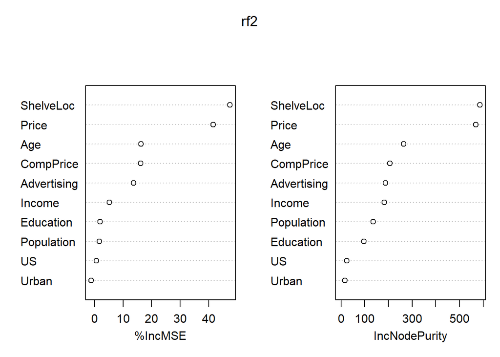

```r
varImpPlot(rf2)
```

**Interpretation:** Random forests performed best with `mtry = 5`. The variable importance plot highlights `ShelveLoc`, `Price`, and `Age` as key predictors.

# 8 🧾 Conclusion

This project demonstrated how tree-based models can be used for regression tasks. Pruning helped control model complexity, while bagging and random forests greatly improved prediction accuracy by reducing variance. Variable importance plots helped identify the most influential factors in predicting product sales.